# Modelado generativo profundo

## Aprendizaje no supervisado

En el aprendizaje no supervisado sólo tenemos un conjunto de datos $x$ pero no conocemos a qué clase pertenece cada una. Entonces neustro objetivo es conocer la estructura o qué información contienen estos datos. Para ello se usa el *clustering* o el análisis de componentes principales.

### Modelado generativo

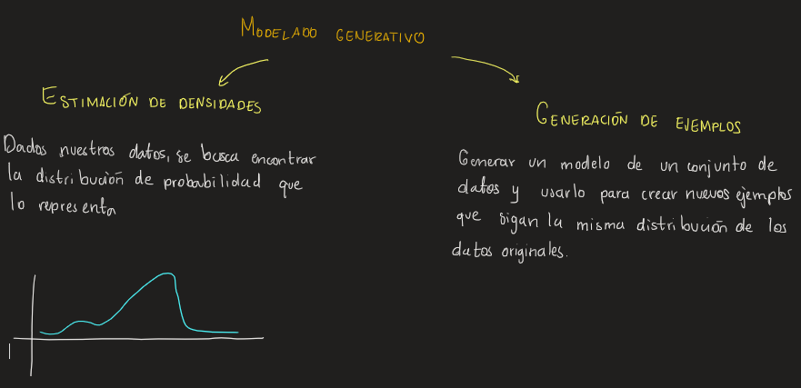

En estos modelos tratamos de hacer que la distribución de probabilidad de nuestro modelo sea similar a la distribución de probabilidad de los datos originales. Otra aplicación de estos modelos es la detección de eventos extraordinarios, así utilizando la dsitribución de probabilidad de nuestros datos podemos identificar aquellos eventos que sean menos probables.

## Autoencoders

Los autoencoders son una serie de capas donde se va disminuyendo la dimensión de las características. Como no tenemos datos para comprobar que nuestra arquitectura funcione correctamente, lo que se hace es que una vez se tienen las características codificadas en un espacio dimensional pequeño, se decodifican de nuevo en un espacio dimensional de los datos originales, para así comprobar que la salida sea igual a la entrada.

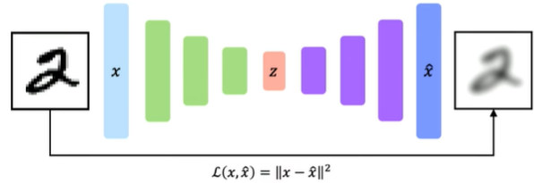

Un autoencoder es una forma de comprimir, por lo que mientras más pequeña sea nuestra dimensión de $z$, entonces tendremos una calidad menor en la salida.

### Autoencoders variacionales VAEs

Los autoencoders son determinísticos, por lo que se introducen elementos estocásticos para poder generar nuevas salidas. En este caso, se divide a nuestro espacio latente $z$ en dos partes, un vector de *media* y un vector de *desviación estándar*. Debido a esto, el codificador lo que tratará de hacer es encontrar la distribución de probabilidad del espacio latente, mientras que el decodificador intentará crear una nueva salida dada la distribución de probabilidad.

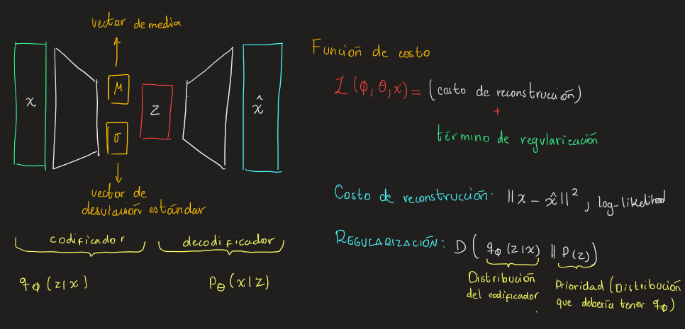

La distribución prioritaria puede ser una gaussiana con media 0 y desviación estándar 1. Esto hace que el espacio latente se encuentre alrededor del centro de la distribución y penaliza cuando la red intenta agrupar puntos en regiones específicas. Para la función de costo se utiliza la divergencia KL, que es una medida de la *distancia* entre dos distribuciones de probabilidad y se define como sigue:

$$ D(q_\phi (z|x) || p(z)) = -\frac{1}{2} \sum_{j=0}^{k-1} (\sigma_j + \mu_j^2 - 1 - \log{\sigma_j}) $$

Lo que se busca con la regularización en el espacio latente son dos cosas:

- **Continuidad**: que dos puntos cercanos en la distribución tengan como resultado decodificaciones similares.
- **Completitud**: que los resultados de la decodificación tengan un significado.

La regularización ayuda a que se logren estas dos características. Al escoger una función gaussiana normal podemos hacer que el espacio latente sea más suave.

#### Entrenamiento

Debido a que añadimos un comportamietno azaroso, no podemos realizar backpropagation de forma efectiva, por lo que la distribución de probabilidad se parametriza en dos vectores, uno de mediay otro de desviación estándar, añadiendo un término $\epsilon$ que toma valores aleatorios de una distribución normal.

$$ z = \mu + \sigma \odot \epsilon $$

donde $\epsilon \approx \mathcal{N} (0,1)$. Con esto ya podemos realizar backprop y aprender los parámetros de la distribución de probabilidad.

Al tener esta perte probabilística, nos permite variar algunas variables latentes y entonces podemos obtener resultados diferentes del mismo espacio manteniendo un significado.

### $\beta$-VAEs

Lo que se quiere con las variables latentes es que cada una aprenda una característica de los datos, así, es necesario que cada una de las variables latentes no estén correlacionadas y sean independientes. Con la arquitectura $\beta$-VAEs se introduce un hiperparámetro $\beta$ que controla qué tan independientes son las variables; con una $\beta > 1$ se obtienen mejores resultados. En este caso, la función de costo tiene dos términos, uno de *reconstrucción* y otro de *regularización*.

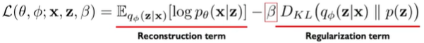

## Redes Generativas Adversarias GANs

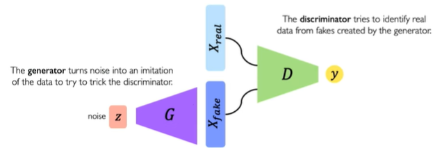

### Entrenamiento

Para el entrenamiento de la arquitectura se usa *cross-entropy*. Para el discriminador tenemos la siguiente función objetivo:

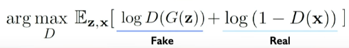

En este caso estamos intentando maximizar la probabilidad de que el discriminador identifique datos falsos como falsos, y reales como reales.

Para el generador tenemos la siguiente función de costo:

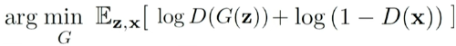

Esta función lo que intenta evitar es que los datos generados sean identificados como falsos, tomando el mínimo, ya que el generador no tiene acceso a los datos reales. Una ve el generador está entrenado, podemos interpolar de forma lineal entre dos puntos del espacio del ruido gaussiano, lo que nos da una interpolación en el espacio de los datos generados.

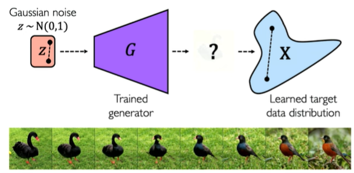

### Avances recientes en GANs

- **Crecimiento progresivo**: Se trata de ir añadiendo capas en el discriminador y el generador conforme se avanza en el entrenamiento, incrementando la resolución de las salidas.
- **StyleGAN**: Se utiliza crecimiento progresivo + transferencia de estilos, de esta manera algunas características se transfieren entre redes para dar nuevos resultados.
- **GANs condicionales**: Se incluye un factor de condicionamiento en la red para controlar la generación. Esto se aplica para traducción de pares; por ejemplo, se intenta generar un par de imágenes, una escena y su segmentación; entonces podemos ir de una segmentación a la creación de una imagen a partir de esta o por ejemplo, la creación de un mapa a partir de una imagen satelital.
- **CycleGAN**: Esta arquitectura aprende transformaciones entre dominios. En este caso tenemos dos GANs con sus propias características, pero tenemos un mapeo adicional entre ambos espacios. Estas pueden utilizarse para transformar audios, cambiando el tono a otro.